# Shiny

## Paso 9 · Deje la receta y espere el visto verde

1. En la portada de su repositorio: **Add file** (o **+**) **→ Create new file**.

[figure not shown]

2. En el nombre, escriba completo, con las barras: `.github/workflows/publicar-app.yml`

[figure not shown]

3. Pegue el contenido de la derecha. Cópielo con el botón.

[figure not shown]

4. Presione **Commit changes…** y confirme.

[figure not shown]

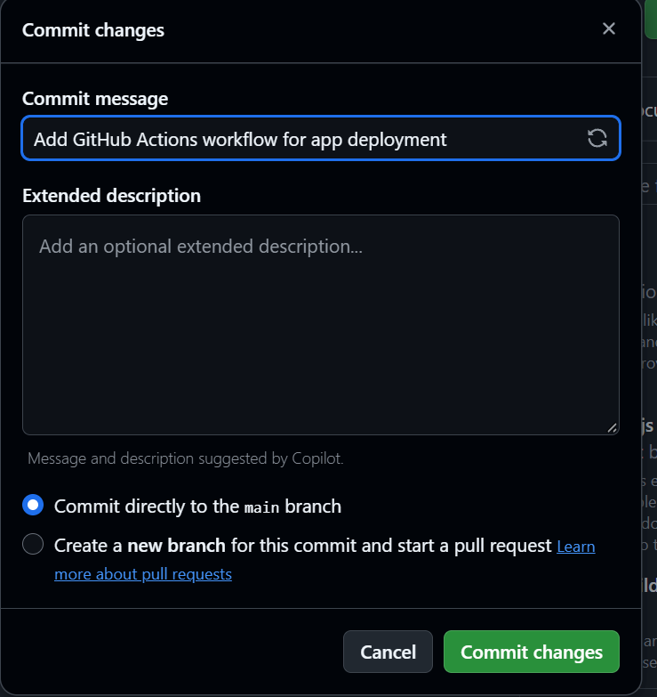

5. Entre a la pestaña **Actions** y espere el visto verde: tarda 5 a 7 minutos.

[figure not shown]

6. Abra `https://USUARIO.github.io/shiny-NOMBRE/`
7. En GitHub Desktop: **Fetch origin** y **Pull origin**. Así baja a su computador el archivo que creó en la web.

[figure not shown]

**¿Cómo sé que funcionó?** Tras un círculo girando, esa dirección muestra su app.

```yaml
# ⚠️ Atención
# La sintaxis es la misma idea que en los YAML usados
# en los encabezados de R Markdown y Quarto:
# - la indentación importa
# - cada nivel "cuelga" del anterior
name: Publicar app en GitHub Pages
# Eventos que activan el workflow
on:
  # Permite ejecutarlo manualmente desde GitHub Actions
  workflow_dispatch:
  # También se ejecuta automáticamente al hacer push
  push:
    # Solo cuando los cambios llegan a la rama main
    branches: ["main"]
# Lo que efectivamente hará
jobs:
  # Nombre del trabajo (puede ser cualquier identificador)
  shinylive:
    # Reutiliza un workflow oficial mantenido por Posit
    uses: posit-dev/r-shinylive/.github/workflows/deploy-app.yaml@actions-v1
    with:
      # Carpeta donde está la aplicación Shiny
      app-dir: app
      # Versión de shinylive a utilizar
      shinylive-version: shinylive
    # Permisos necesarios para publicar en GitHub Pages
    permissions:
      # Permite escribir en GitHub Pages
      pages: write
      # Permite autenticarse mediante tokens OIDC
      id-token: write
```

**Ojo.** Los espacios al inicio de cada línea importan. **¿Equis roja en Actions?** Revise el paso 8, abra la ejecución y presione **Re-run all jobs**.

# Parte 5 · Publicar con servidor

Posit Connect Cloud, desde RStudio. Pasos 10 a 13.

## Paso 10 · Cree su cuenta en Connect Cloud

1. Entre a **connect.posit.cloud**.

[figure not shown]

2. Presione **Sign Up**.
3. Elija registrarse con **GitHub** y autorice.

Así no crea otra contraseña.

**¿Cómo sé que funcionó?** Entra a su página de inicio de Connect Cloud, todavía sin contenido.

**No confunda.** **Posit Cloud** es RStudio en línea. **Posit Connect Cloud** es para publicar.

## Paso 11 · Publique desde RStudio

1. En RStudio: **Tools → Global Options → Publishing → Connect… → Posit Connect Cloud**.

[figure not shown]

2. Se abre el navegador (si lo pide, entre con GitHub): presione **Continue** y autorice.

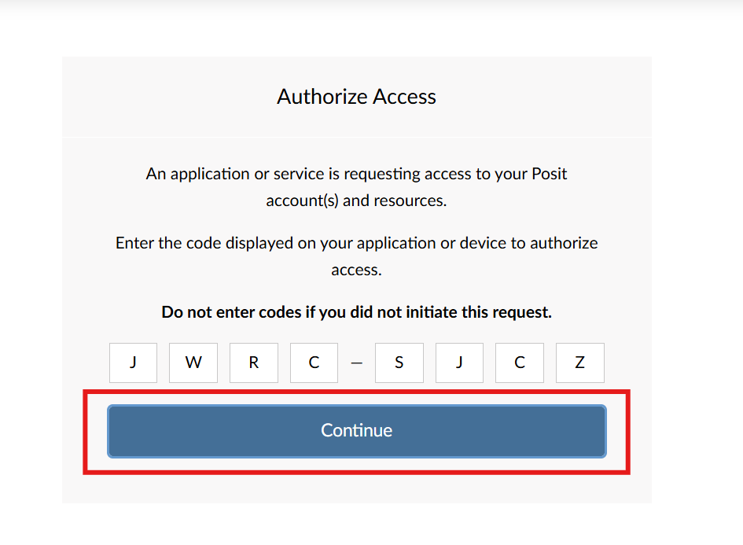

3. Vuelva a RStudio. Con `app.R` abierto, presione **Publish**, a la derecha de **Run App**.

[figure not shown]

4. Revise que `app.R` esté marcado, escriba un **Title** (por ejemplo, `shiny-maria`) y presione **Publish**.

**¿Cómo sé que funcionó?** Tras unos minutos, RStudio abre su app en una dirección que termina en `share.connect.posit.cloud`.

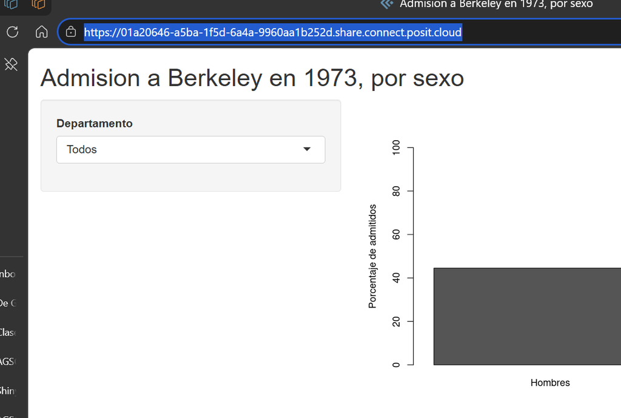

**¿Qué pasó?** RStudio subió la carpeta `app` directo, sin pasar por GitHub. Dejó una carpeta `app/rsconnect` que recuerda dónde publicó. Para actualizar: **Publish** otra vez.

**¿No aparece Posit Connect Cloud?** En la consola: `rsconnect::connectCloudUser()` y después `rsconnect::deployApp("app")`.

## Paso 12 · Otra vía, desde GitHub (1 de 2)

Connect Cloud también puede sacar la app de su repositorio y republicarla sola con cada push. Para eso necesita la lista de paquetes en un archivo: `manifest.json`.

1. En RStudio, con `app.R` abierto: **Session → Set Working Directory → To Source File Location**.

[figure not shown]

2. En la consola:

```r
rsconnect::writeManifest()
```

3. En GitHub Desktop: mensaje `Agrega manifest para Connect Cloud`, **Commit to main** y **Push origin**.

**¿Cómo sé que funcionó?** En la carpeta `app` hay un archivo nuevo, `manifest.json`, y ya está en github.com.

[figure not shown]

**¿Qué es `manifest.json`?** La lista de compras de Connect Cloud: su servidor parte sin paquetes e instala la versión de R y los paquetes que dice ahí. Es la misma idea del `renv.lock` de la primera clase. Si agrega un paquete a la app, vuelva a correr `writeManifest()`.

## Paso 12 · Otra vía, desde GitHub (2 de 2)

1. En connect.posit.cloud, en **Home**, presione **Publish**. La primera vez le pide instalar la aplicación de Connect Cloud en GitHub: acepte.
2. Elija **Shiny**.
3. Elija su repositorio `shiny-…`. El plan gratuito pide que sea **público**: el suyo lo es.
4. **Branch**: `main`.
5. **Primary file**: `app/app.R`.
6. Deje activado **Automatically publish on push**.
7. Presione **Publish**.

**¿Cómo sé que funcionó?** Tras unos minutos de instalación, aparece su app en otra dirección `share.connect.posit.cloud`. Es una copia distinta de la del paso 11.

**¿Falla la publicación?** Lea el registro que muestra la página. Lo más común: falta `manifest.json` en la carpeta `app`, o no se hizo push.

## Paso 13 · Cambie algo y mire sus tres direcciones

1. En `app.R`, cambie el otro color del gráfico: `"#555555"` por `"orange"`.
2. Guarde, y en GitHub Desktop haga **commit** y **push**.
3. En RStudio, presione **Publish** otra vez.
4. Espere unos minutos y recargue sus tres direcciones.

**¿Qué debe ver?**

- **GitHub Pages** muestra el color nuevo: se publicó sola con el push.
- **Connect Cloud** también: la republicó usted con **Publish**. Por la vía de GitHub se republica sola.
- **El enlace del paso 7** sigue igual: es una copia guardada dentro de la dirección.

# Cierre

## Tres formas de publicar la misma app

|  | Enlace de shinylive | GitHub Pages + Actions | Posit Connect Cloud |
| --- | --- | --- | --- |
| ¿Dónde corre R? | En el navegador de quien visita | En el navegador de quien visita | En un servidor de Posit |
| ¿Qué necesita? | Nada | Un repositorio público | Una cuenta |
| Primera carga | Lenta | Lenta | Rápida |
| Los datos | Viajan completos a quien visita | Viajan completos a quien visita | Se quedan en el servidor |
| Paquetes | Solo los preparados para navegador | Solo los preparados para navegador | Casi todos los de CRAN |
| Para actualizar | Crear un enlace nuevo | Solo push | **Publish** otra vez (o solo push, por la vía de GitHub) |

En los tres casos el código queda a la vista de cualquiera. Con datos que identifican personas, ninguna sirve tal como está.

## Si algo falla

| Lo que ve | Qué hacer |
| --- | --- |
| El editor vivo queda en blanco | Use el enlace *Abrir este editor en una pestaña nueva*, o recargue la página. |
| R o RStudio no funcionan en su computador | Entre a posit.cloud, cree un proyecto de RStudio y siga ahí los pasos 1, 3, 4 y 11. |
| No tiene GitHub Desktop (por ejemplo, en Linux) | Cree `app/app.R` en github.com con **Add file → Create new file**, igual que en el paso 9. |
| **Run App** da un error | Vuelva a copiar el código completo. Casi siempre falta una coma o un paréntesis. |
| Equis roja en **Actions** | Revise que en el paso 8 diga *GitHub Actions* y que la carpeta se llame `app`. Después, **Re-run all jobs**. |
| La dirección de GitHub Pages da **404** | Espere a que Actions termine con visto verde y recargue. |
| Connect Cloud no publica | Desde RStudio: lea el error en la pestaña **Deploy**. Desde GitHub: revise que `manifest.json` esté en `app` y que hizo push. |
| Nada de lo anterior resulta | Su enlace del paso 7 sigue funcionando. Avise y siga con la persona de al lado. |

## Lo que hizo hoy

- Armó una app pieza por pieza: página, control, resultado, gráfico y orden.
- Hizo una app con datos reales y encontró algo que una tabla fija escondía.
- La publicó de tres formas.
- Vio que un push puede actualizar una app publicada.

**Para seguir**

- **Desafío:** la misma idea con la ENSSEX. Código en app-enssex.R; necesita `enssex_base1.csv` en la carpeta `app`.
- [Mastering Shiny](https://mastering-shiny.org/), de Hadley Wickham. Libre en línea.
- La [clase de Shiny de 2025](https://github.com/JoseRTM/Reproducibilidad-UDP/tree/main/Clase4_Shiny), de José Ruiz-Tagle Maturana: más diseños de pantalla, filtros y tableros.

## Fuentes

- González-Santa Cruz, A. (2024). *Clase 5: Shiny*. Diplomado en Data Science para las Ciencias Sociales, UDP. https://agscl.github.io/repr/clase5.html
- Ruiz-Tagle Maturana, J. (2025). *Reproducibilidad-UDP, clase 4: Shiny* [repositorio de GitHub]. https://github.com/JoseRTM/Reproducibilidad-UDP
- Wickham, H. (2021). *Mastering Shiny*. O’Reilly. https://mastering-shiny.org/
- Posit. *Connect Cloud: Deploy a Shiny for R application*. https://docs.posit.co/connect-cloud/how-to/r/shiny-r.html
- Posit. *shinylive para R*, con su receta de GitHub Actions para publicar en GitHub Pages. https://posit-dev.github.io/r-shinylive/
- Bickel, P. J., Hammel, E. A. y O’Connell, J. W. (1975). Sex bias in graduate admissions: Data from Berkeley. *Science*, 187(4175), 398–404. Datos incluidos en R como `UCBAdmissions`.

Código de estas diapositivas: https://github.com/AGSCL/repr2026

## Antes de irse: ¿cómo estuvo la clase?

[figure not shown]

Apunte la cámara del teléfono al código y responda la encuesta de la clase.

Cuente qué le sirvió, qué quedó confuso y qué cambiaría. Con eso se ajusta la próxima sesión.

[figure not shown]